# Final R code and Analysis

D.M. Burt, S. Pelkey, M. Pera

December 9, 2016

### Step 1: Preparing data

#### Loading and cleaning data

The R script below loads and cleans our dataset for analysis. First, the data set was created by merging three different publicly available datasets using SQL (see SQL scripting doc). This data set is then uploaded into R. This data set contains 3127 hospitals with 36 features, which include financial variables, hospital administrative information, and information about other hospitals within the hospital’s medicare referral region (referred to as HRR throughout).

As the analysis for this project is dependent on financial information from 2013 and 2014 (and, in particular, analyzing the change between the two years), hospitals that have $0 in charges for either 2013 or 2014 are excluded from analysis. A charge of $0 for a year indicates that the hospital was not in business that year, and we are only interested in hospitals that were in operation during both 2013 and 2014. Additionally, we exclude hospitals for which the average charges of their HRR are $0 in 2013 (5 hospitals total). This is likely a data entry error, and as we divide by the average HRR charges for analysis, we must exclude the hospitals for which the denominator is 0. Additionally, there are two hospitals that contain ungroupable diagnositc-related groups (DRGs), which means that their adjusted charges are unreasonably high and unreasonably low; we exclude these outliers as valid adjusted charges are imperative for our analysis. Finally, there are 45 hospitals with missing bed counts and one hospital with a bed count of 1, which is a huge outlier. Bed count is a necessary covariate for our analysis, and after making sure that excluding these hospitals would not significantly impact analysis, we drop these observations. The final clean dataset still contains 3074 of the original 3127 hospitals (98.3%).

It is worth noting that we plan to do analysis on how a hospitals charges might be related to the charges of the hospitals nearby, and yet we are excluding hospitals from analysis. One might be concerned that by excluding hospitals, we are decreasing the pool of “neighboring” hospitals, and therefore our analyses on remaining hospitals will be affected. This would be true if we had not already done all necessary calculations in SQL; since all of our competitor variables have already been created on a full dataset of all hospitals, we can drop observations without affecting the remaining hospitals.

```r
# Loading libraries needed for the project
library(dplyr)
library(tidyr)
library(ggplot2)
library(stargazer)
library(car)
library(lmtest)
library(ivpack)
library(effects)
library(maps)
library(knitr)

# Step 1: Upload and clean data
# This script uploads the most recent data, cleans it, and creates all variables needed for analysis
# The output is a dataframe that will be used for the enirity of analysis

# loading data and saving to a dataframe
setwd("~/Desktop/Cal/MIDS/271/271 final project/")
d <- read.delim("W271_Lab3_Dataset_By_Hosp.txt")

#setwd("c:/Users/Steve/Documents/mids/w_271/project/W271/Data/R/")
#d <- read.delim("../../../W271_Lab3_Dataset_By_Hosp.txt")

# Excluding hospitals that have no charges in either 2013 or 2014 (or both)
d <- d[ which(d$FY2013_AVG_CHG!=0 & d$FY2014_AVG_CHG!=0), ]

# Excluding hospitals for which HRR averages are 0
d = d[d$HRR_FY2013_AVG_CHG_EXCLUDING_HOSP != 0,] # only exists in unadjusted averages

# Removing big outliers due to ungroupable DRG's
d = d[which(d$DIFF_14_13_ADJUSTED_AVG_CHG < 79000 & d$DIFF_14_13_ADJUSTED_AVG_CHG > -33000),]

# Check for missing values
check_na <- sapply(d, function(x) sum(is.na(x))) # missing values only exist for bed count
```

```r
# Check if dropping na bed counts will significantly impact analysis
d$BED_CNT_NA = is.na(d$BED_CNT)
#relationship with dependent
stargazer(d %>% group_by(BED_CNT_NA) %>%
            summarise(count = n(),
                      avg = mean(DIFF_14_13_ADJUSTED_AVG_CHG, na.rm = T),
                      median = median(DIFF_14_13_ADJUSTED_AVG_CHG, na.rm = T),
                      stdv = sd(DIFF_14_13_ADJUSTED_AVG_CHG, na.rm = T),
                      min = min(DIFF_14_13_ADJUSTED_AVG_CHG, na.rm = T),
                      max = max(DIFF_14_13_ADJUSTED_AVG_CHG, na.rm = T)) %>%
            data.frame(), type = "text",
          title = "Missing Bed Count on Dependent Variable",summary = F)
#not significant
t.test(data = d, DIFF_14_13_ADJUSTED_AVG_CHG ~ BED_CNT_NA)
#relationship with independent variable
stargazer(d %>% group_by(BED_CNT_NA) %>%
            summarise(count = n(),
                      avg = mean(FY2013_ADJUSTED_AVG_CHG_RELATIVE_EX, na.rm = T),
                      median = median(FY2013_ADJUSTED_AVG_CHG_RELATIVE_EX, na.rm = T),
                      stdv = sd(FY2013_ADJUSTED_AVG_CHG_RELATIVE_EX, na.rm = T),
                      min = min(FY2013_ADJUSTED_AVG_CHG_RELATIVE_EX, na.rm = T),
                      max = max(FY2013_ADJUSTED_AVG_CHG_RELATIVE_EX, na.rm = T)) %>%
            data.frame(), type = "text",
          title = "Missing Bed Count on Independent Variable",summary = F)
#not significant
t.test(data = d, FY2013_ADJUSTED_AVG_CHG_RELATIVE_EX ~ BED_CNT_NA)
```

```r
# Since hospitals with bed count NAs do not significantly impact analysis, we remove them, leaving a data frame with only complete cases and no outliers
d = d[d$BED_CNT>1,]
d = d[complete.cases(d),]
```

#### Variable creation

Our outcome variable is the change in charges for a hospital between 2013 and 2014, which has been calculated using SQL. However, we must still calculate our main predictor variables in R, which is completed in the following script. The predictor variable is the percent that a hospital is above or below their competitors. To calculate this, we divide the average charge for a hospital in 2013 by the average charge of its competitors, multiply by 100 to get a percentage, and subtract 100 to obtain the percent that a hospital is above or below their competition. We calculate this variable for both adjusted and unadjusted costs. The unadjusted average cost is the raw average cost per procedure that a hospital reports for 2013, and the unadjusted average competitor cost is the raw average cost per procedure that all of the other hospitals within a hospital’s HRR charge in 2013. The adjusted cost takes the raw cost and divides by the DRG weight, which normalizes the costs across hospitals. For example, a hospital that does mainly heart surgery will have a higher average unadjusted cost than a hospital that generally does routine procedures; when costs are adjusted with the DRG weight provide by CMS, you can then compare apples to apples without worrying about the complexity of procedures that a hospital performs. For our final model we focus on the adjusted relative costs, but we run models using the unadjusted relative costs as well for comparison.

After calculating our main predictor variables, we create a few other predictors of interest to use as covariates. These variables are thought to explain some of the variance in cost between hospitals and are worth controlling for. These include the number of providers employed by a hospital, the number of medicare beneficiaries per hospital within an HRR, the number of beds per thousand beneficiaries, the number of discharges per bed in various years, and dummy variables for rural/urban, the presence of a residency program, and whether the hospital is a for-profit hospital.

```r
# Creating independent relative variables for regression
# Relative percent, unadjusted
d$FY2013_AVG_CHG_RELATIVE_EX = 100*(d$FY2013_AVG_CHG/d$HRR_FY2013_AVG_CHG_EXCLUDING_HOSP) - 100
# Relative percent, adjusted
d$FY2013_ADJUSTED_AVG_CHG_RELATIVE_EX = 100*(d$FY2013_ADJUSTED_AVG_CHG/d$HRR_FY2013_ADJUSTED_AVG_CHG_EXCLUDING_HOSP) - 100

# Creating other explanatory variables of interest
d$N_PROVIDERS = d$N_NURSES + d$N_PHYSICIANS
d$BENEFICIARIES_PER_PROVIDER = d$PART_A_BENEFICIARIES/d$N_HOSPS_IN_HRR/1000
d$BED_CNT_PER_THOUSAND_BENEFICIARIES = d$BED_CNT/d$BENEFICIARIES_PER_PROVIDER

# Create percent of HRR that urban and have residency program
d$URBAN_DUMMY = ifelse(d$URBAN_RURAL_IND =='U',1,0)
d$RESIDENCY_PROGRAM_DUMMY = ifelse(d$RESIDENCY_PROGRAM_IND=='Y',1,0)
d = d %>% group_by(HRR) %>%
  summarise(HRR_PERCENT_URBAN = mean(URBAN_DUMMY, na.rm =T)*100,
            HRR_PERCENT_RESIDENT = mean(RESIDENCY_PROGRAM_DUMMY, na.rm = T)*100) %>%
  right_join(d, by = 'HRR')

# Create discharges per bed count
d$FY2012_DISCHARGES_PER_BED = d$N_FY2012_DISCHARGES/d$BED_CNT
d$FY2013_DISCHARGES_PER_BED = d$N_FY2013_DISCHARGES/d$BED_CNT
d$DIFF_13_12_DISCHARGES_PER_BED = d$FY2013_DISCHARGES_PER_BED - d$FY2012_DISCHARGES_PER_BED

# Create dummy variable for private for profit hospitals, save as a factor
d$OWNERSHIP_FOR_PROFIT = ifelse(d$TYPE_OF_OWNERSHIP == 'PRIVATE FOR PROFIT',1,0)
d$OWNERSHIP_FOR_PROFIT <- as.factor(d$OWNERSHIP_FOR_PROFIT)
```

#### Data frame creation

Finally, we create a few other data frames that are subsets of our main data frame.

We thought it might be intersting to run separate regressions for hospitals that increased their costs above the level of inflation and hospitals that did not increase costs above inflation. There might be something different about how these hospitals respond to variables that we would miss by only doing analysis on the full dataset together. The CMS market basket set inflation at 2% for 2013, so this is the cutoff that we use to split the dataset into hospitals over inflation and hospitals under inflation.

We also create a dataframe that groups by HRR to do some exploratory data analysis on our data at the HRR level, rather than solely at the hospital level.

```r
# Splitting data by over/under inflation
# Calculate inflation
d$INFLATION_ADJUSTED_2014 <- ((d$FY2014_ADJUSTED_AVG_CHG - d$FY2013_ADJUSTED_AVG_CHG)/d$FY2013_ADJUSTED_AVG_CHG)*100
# Split data by greater/less than 2.0%
inflation_over <- d[d$INFLATION_ADJUSTED_2014 >2.0,]
inflation_under <- d[d$INFLATION_ADJUSTED_2014 <= 2.0,]

# Grouping by HRR and saving to a dataframe
HRR = d %>% group_by(HRR) %>%
  summarise(FY2013_ADJUSTED_AVG_CHG = mean(FY2013_ADJUSTED_AVG_CHG, na.rm = T),
            FY2014_ADJUSTED_AVG_CHG = mean(FY2014_ADJUSTED_AVG_CHG, na.rm = T))
```

### Step 2: Exploratory data analysis

The chart below shows the relationship between the number of hospitals in each HRR and the DRG-adjusted average charges in the HRR. There is an upward trending line summarizing these data, indicating that as the number of hospitals in an HRR increase, the average charge for that HRR also increases. However, this might be skewed by a few large and expensive HRRs. Notably, all of the hospitals that charge on average $70,000 for care or higher are in hospital referral regions with 10 hospitals or fewer. This supports the idea that lack of local competition is a factor in rising health care costs. However, super expensive hospitals seem to be in the minority; most hospital referral regions have more reasonable average adjusted charges. Additionally, it is worth noting that the most expensive hospitals are for the most part located in urban regions.

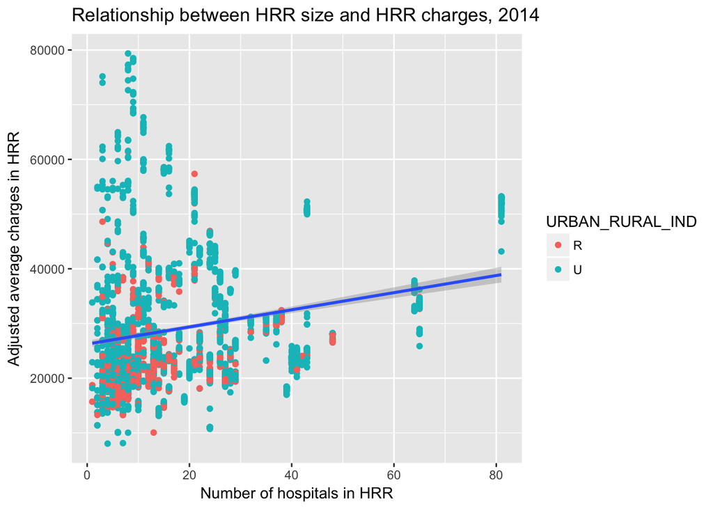

```r
# Plot of HRR size and average charge
ggplot(d, aes(d$N_HOSPS_IN_HRR, d$HRR_FY2014_ADJUSTED_AVG_CHG_INCLUDING_HOSP)) +
  geom_point(aes(colour = URBAN_RURAL_IND)) + geom_smooth(method = "lm") +
  labs(title="Relationship between HRR size and HRR charges, 2014") +
  labs(x="Number of hospitals in HRR", y="Adjusted average charges in HRR")
```

The following plot shows the relationship between hospital adjusted average charges and adjusted average charges for the hospitals within the hospital’s HRR. As one might expect, there is a positive trending relationship between hospital charges and the average charges of their competitors within their own HRR. Again, expensive hospitals and HRRs seem to be more common in urban areas.

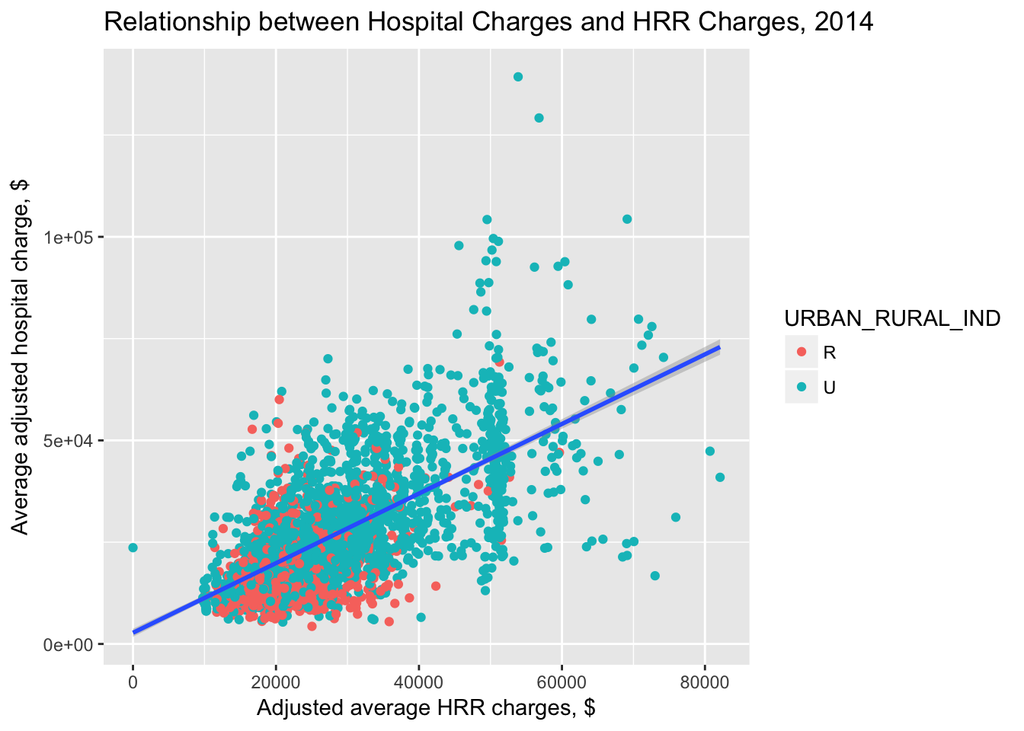

```r
ggplot(d, aes(HRR_FY2012_ADJUSTED_AVG_CHG_EXCLUDING_HOSP, d$FY2013_ADJUSTED_AVG_CHG))+
  geom_point(aes(colour = URBAN_RURAL_IND)) + geom_smooth(method = "lm") +
  labs(title="Relationship between Hospital Charges and HRR Charges, 2014") +
  labs(y="Average adjusted hospital charge, $", x="Adjusted average HRR charges, $")
```

#### Outcome Variable

The the main outcome variable of interest is change in charges for a hospital between 2013 and 2014. We start by looking at the relationship between hospital average adjusted charges in 2013 and 2014. The scatterplot below reveals that they are closely related, with a trendline roughly on the 45 degree slope (indicating that x = y). Indeed, the correlation between the two variables is 0.985. This scatterplot also shows the range of average adjusted charges in the dataset, with hospitals charging as low as ~$4000 to as high as ~$140,000. The rest of the analysis will focus on the change between adjusted charges from 2013 to 2014 in the same hospital, taking care of inter-hospital differences in charges that are present at the outset.

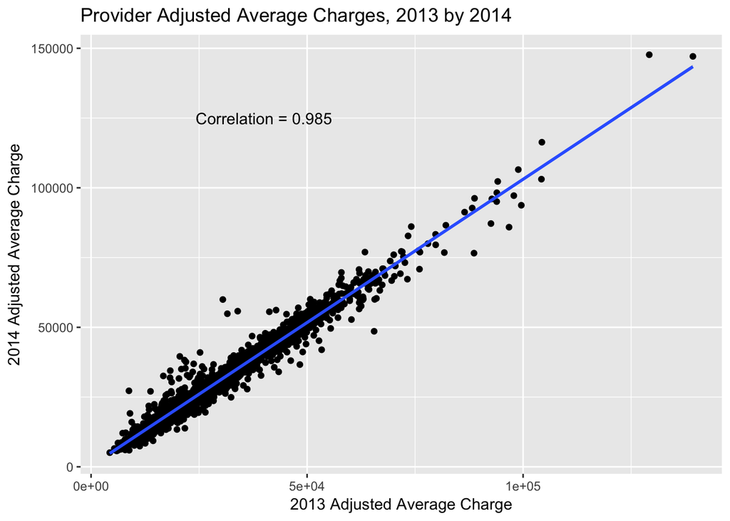

```
##    Min. 1st Qu.  Median    Mean 3rd Qu.    Max.
##    4325   16330   22420   25970   31690  139300
```

```
## [1] 0.9852574
```

```r
# Examining the main outcome variable: DIFF_14_13_ADJUSTED_AVG_CHG
stargazer(d$DIFF_14_13_ADJUSTED_AVG_CHG %>% data.frame(),
          type = "text", iqr = T, median = T,
          title = "Hospital Difference in Adjusted Charges, 2013")
```

```
##
## Hospital Difference in Adjusted Charges, 2013
## =====================================================================================
## Statistic   N     Mean    St. Dev.      Min     Pctl(25) Median  Pctl(75)     Max
## -------------------------------------------------------------------------------------
## .         3,074 1,055.153 2,548.220 -16,943.200 -111.398 810.853 1,949.716 29,461.290
## -------------------------------------------------------------------------------------
```

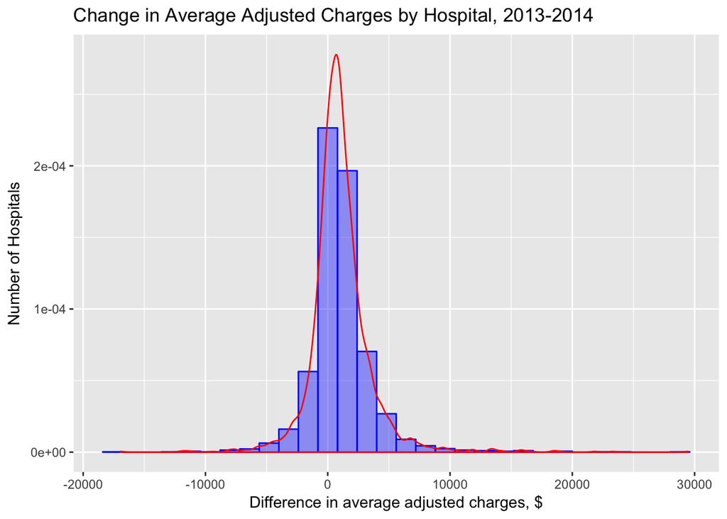

```r
# Histogram of distribution
ggplot(data=d, aes(d$DIFF_14_13_ADJUSTED_AVG_CHG)) +
  geom_histogram(aes(y =..density..), col="blue", fill="blue", alpha = .4) +
  labs(title="Change in Average Adjusted Charges by Hospital, 2013-2014") +
  labs(x="Difference in average adjusted charges, $", y="Number of Hospitals") +
  geom_density(col='red')
```

#### Predictor Variables

The two main predictor variables in this project are the percent difference in average adjusted costs for a hospital relative to its competitors, and the percent difference in average unadjusted costs for a hospital relative to its competitors.

Below is a summary output for the unadjusted version of the variable. The peak of the distribution is slightly to the left of 0, and the overall distribution is skewed towards the right.

```
##
## Hospital Difference in Adjusted Charges, 2013
## =========================================================================
## Statistic   N    Mean  St. Dev.   Min   Pctl(25) Median  Pctl(75)   Max
## -------------------------------------------------------------------------
## .         3,074 -6.472  38.734  -84.727 -32.642  -11.381  11.731  293.605
## -------------------------------------------------------------------------
```

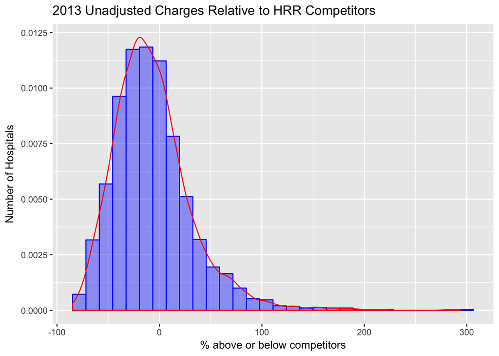

Below is a summary output for the adjusted version of the variable, and an accompanying histogram. The histogram for the adjusted charges relative to competitors looks much more normally distributed, which makes sense as the adjusted charges normalize for hospitals doing different types of procedures. The mean of this distribution is still slightly negative, and there is still a right skew with large outliers tailing off to the right. However, the skew is not as pronounced as in the previous graph.

```
##
## Hospital Difference in Adjusted Charges, 2013
## =========================================================================
## Statistic   N    Mean  St. Dev.   Min   Pctl(25) Median  Pctl(75)   Max
## -------------------------------------------------------------------------
## .         3,074 -7.070  35.623  -84.727 -30.661  -10.987  10.213  208.316
## -------------------------------------------------------------------------
```

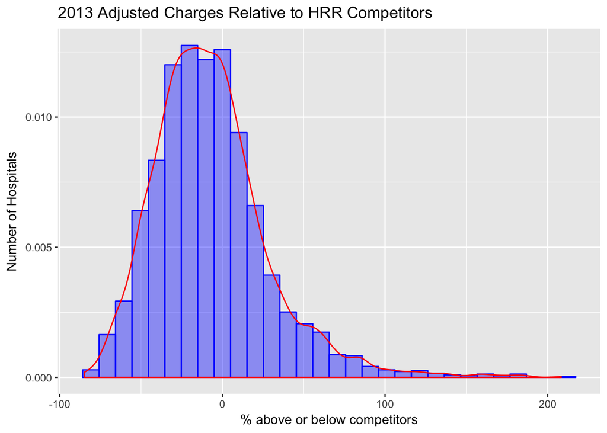

#### Formally checking for normality

The Shapiro-Wilk tests for these three variables (the outcome variable and two predictor variables) are all significant, meaning we reject the null hypothesis of an underlying normal distribution. However, since there are so many observations in our dataset, we can rely on the central limit theorem to fulfil the assumptions of a normal distribution.

```r
# Check for normality with Shapiro-Wilk test
shapiro.test(d$DIFF_14_13_ADJUSTED_AVG_CHG)
shapiro.test(d$FY2013_AVG_CHG_RELATIVE_EX)
shapiro.test(d$FY2013_ADJUSTED_AVG_CHG_RELATIVE_EX)
```

#### Investigating relationship between outcome and predictor variables

The scatterplots below show the relationships between the outcome and predictor variables, with the unadjusted predictor variable on the left and the adjusted predictor variable on the right. As is expectied, the unadjusted trendline shows a steeper slope, and the adjusted trendline is more horizontal. This makes sense because there is more variation overall in the unadjusted variable (higher highs and lower lows), and the adjusted variable is more normalized. Indeed, the adjusted variable has less variation in both the y and the x direction and is more centered around the trendline in general. Because of this, and because it is more valid to make comparisons based on normalized charges, we will use adjusted charges for both our outcome and predictor variables for our official analysis. We will do analysis on the unadjusted data only for comparative purposes.

It is worth noting that both trendlines are positive-sloping, indicating that hospitals who have higher charges relative to their competitors 2013 tend to increase their prices more from 2013 to 2014 than hospitals that have lower charges relative to their competitors in 2013. This is counter-intuitive to our hypothesis, which is that hospitals respond to local competition, implying that a hospital with higher charges relative to competitors might bring their charges down in order to be competitive in their region. We will continue to explore this relationship with regressions and control for covariates that might account for some of the upward trend.

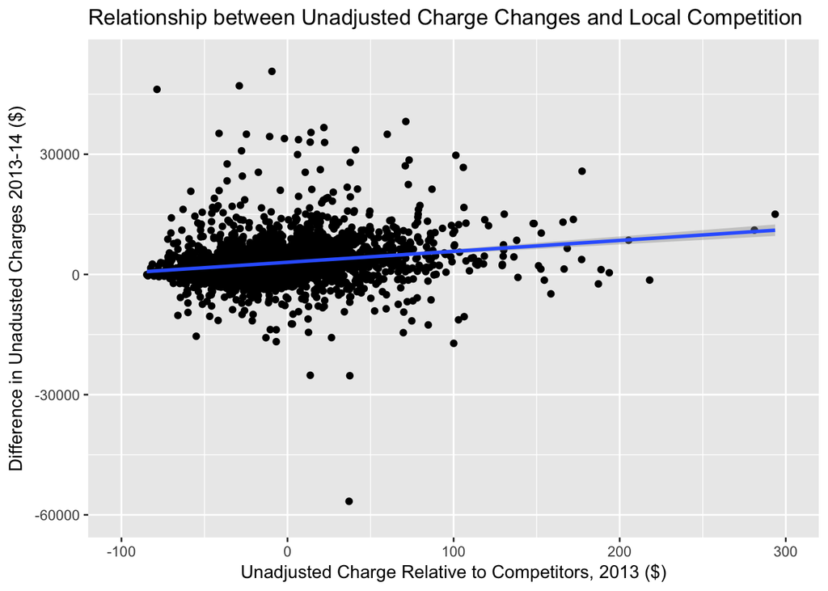

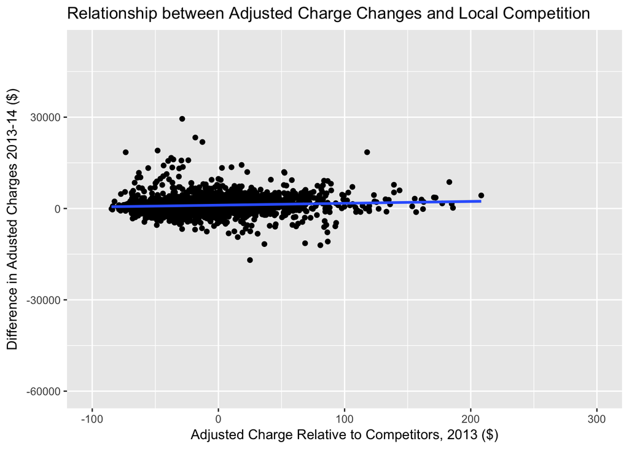

#### EDA for covariates: estimating competitiveness in local markets

In theory, the size of the HRR market relative to the number of providers should influence adjusted charges since the number of available consumers in a market will help determine the price of goods. We used the average number of Part A beneficiaries per hospital in an HRR as a proxy for this phenomenon. Indeed, we observe a positive relationship between the number of beneficiaries per provider and the change in adjusted average charges from 2013-2014 (see output below). The correlation coefficient between these two variables is small but significant. This suggests that as the number of beneficiaries per provider increases, the increase in cost of care from 2013-2014 also rises. As this relationship is significant, we will include it in later regressions.

```
##
## Part A Beneficiaries per Provider (in thousands)
## =====================================================================
## Statistic   N    Mean  St. Dev.  Min  Pctl(25) Median Pctl(75)  Max
## ---------------------------------------------------------------------
## .         3,074 11.204  4.169   3.176  8.383   10.352  13.341  31.506
## ---------------------------------------------------------------------
```

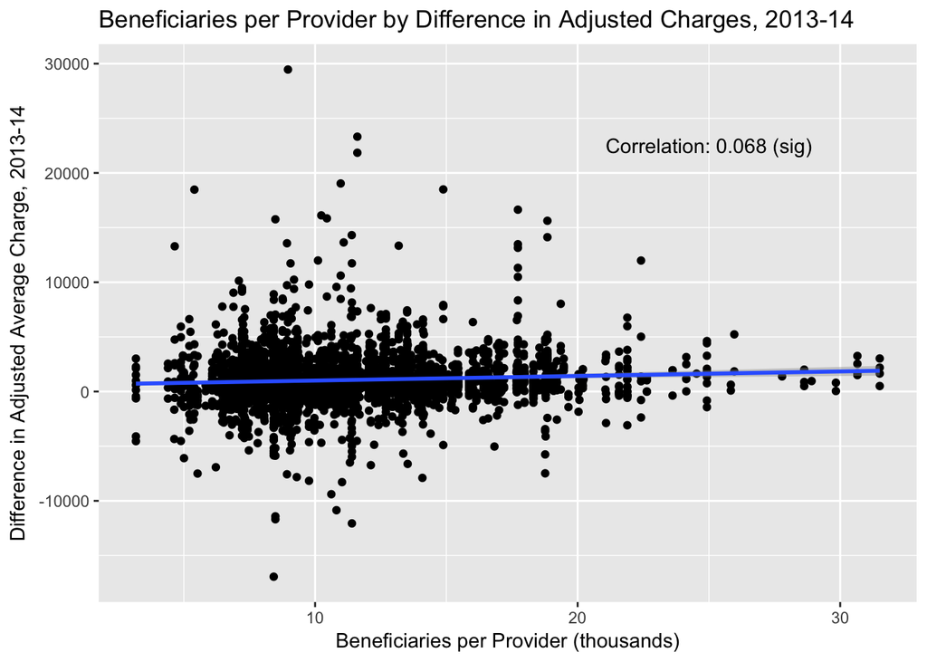

```r
# Checking out the distribution of beneficiaries per provider
hist(d$BENEFICIARIES_PER_PROVIDER, breaks = 20)
qqPlot(d$BENEFICIARIES_PER_PROVIDER)
shapiro.test(d$BENEFICIARIES_PER_PROVIDER) # sig, reject null of normality

# Summary of beneficiaries per provider
stargazer(d$BENEFICIARIES_PER_PROVIDER %>% data.frame(),
          type = "text", iqr = T, median = T,
          title = "Part A Beneficiaries per Provider (in thousands)")

#slight positive relationship with dependent variable
ggplot(d, aes(BENEFICIARIES_PER_PROVIDER, DIFF_14_13_ADJUSTED_AVG_CHG)) +
  geom_point() + geom_smooth(method = 'lm') +
  ggtitle("Beneficiaries per Provider by Difference in Adjusted Charges, 2013-14") +
  labs(x = "Beneficiaries per Provider (thousands)", y = "Difference in Adjusted Average Charge, 2013-14") +
  annotate("text", x = 25, y = 22500, label = "Correlation: 0.068 (sig)")

# Correlation is small, but significant; perhaps accounts for some variance
cor.test(d$BENEFICIARIES_PER_PROVIDER, d$DIFF_14_13_ADJUSTED_AVG_CHG, use = "pairwise.complete.obs")
```

#### EDA for covariates: bed count per thousand beneficiaries

We are using bed count as a proxy for the size of the provider. More precisely, we are using bed count per thousand beneficiaries in the HRR as a proxy for the capacity of the provider to provide care to the beneficiaries within their own HRR. Below we explore the overall distribution of this variable. This variable also has a slight but significant positive correlation with the dependent variable and will be used in later regressions.

```
##
## Bed Count per Thousand Part A Beneficiaries
## ======================================================================
## Statistic   N    Mean  St. Dev.  Min  Pctl(25) Median Pctl(75)   Max
## ----------------------------------------------------------------------
## .         3,074 23.102  23.512  0.287  8.576   15.754  28.607  306.191
## ----------------------------------------------------------------------
```

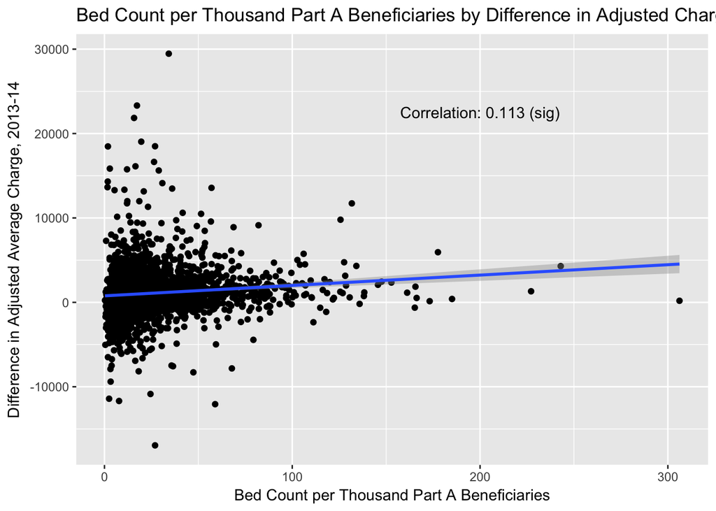

```r
#Summary stats
stargazer(d$BED_CNT_PER_THOUSAND_BENEFICIARIES %>% data.frame(),
          type = "text", iqr = T, median = T,
          title = "Bed Count per Thousand Part A Beneficiaries")

#Distribution: poisson-esque
hist(d$BED_CNT_PER_THOUSAND_BENEFICIARIES, breaks = 20,
     main = "Bed Count per Thousand Part A Beneficiaries")
qqPlot(d$BED_CNT_PER_THOUSAND_BENEFICIARIES)
shapiro.test(d$BED_CNT_PER_THOUSAND_BENEFICIARIES) # reject null of normality

#Slight positive relationship with dependent variable
ggplot(d, aes(BED_CNT_PER_THOUSAND_BENEFICIARIES, DIFF_14_13_ADJUSTED_AVG_CHG)) +
  geom_point() + geom_smooth(method = 'lm') +
  ggtitle("Bed Count per Thousand Part A Beneficiaries by Difference in Adjusted Charges, 2013-14") +
  labs(x = "Bed Count per Thousand Part A Beneficiaries", y = "Difference in Adjusted Average Charge, 2013-14")
cor(d$BED_CNT_PER_THOUSAND_BENEFICIARIES, d$DIFF_14_13_ADJUSTED_AVG_CHG, use = "pairwise.complete.obs")
```

#### EDA for covariates: Urban and Rural

It is well established that urban areas are more expensive than rural areas, and could thus have a large impact on provider charges. There are two variables in the dataset denoting rural/urban discrepancies: 1) percent of providers in an HRR that are urban, 2) the urban/rural status of an individual provider. Either or both (potential interaction) could have an impact on adjusted charges.

The overlapping distribution curves for the dependent variable by rural/urban indicator reveal that urban areas have a distributino that is slightly more skewed to the right than rural areas; rural areas have a larger peak around 0, indicating no (or very little) increase in hospital charges from 2013-2014.

```
##
## Difference in Adjusted Average Charge, 2013-14 by Urban/Rural
## ==========================================================================
##   URBAN_RURAL_IND count    avg    median    stdv        min        max
## --------------------------------------------------------------------------
## 1        R         847   650.866  569.735 1,960.629 -11,686.190 18,474.560
## 2        U        2,227 1,208.916 922.122 2,723.490 -16,943.200 29,461.290
## --------------------------------------------------------------------------
```

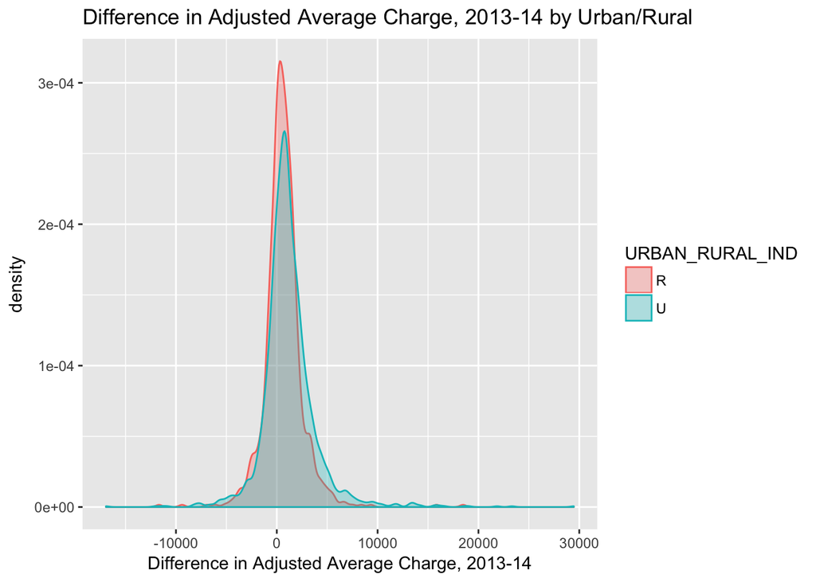

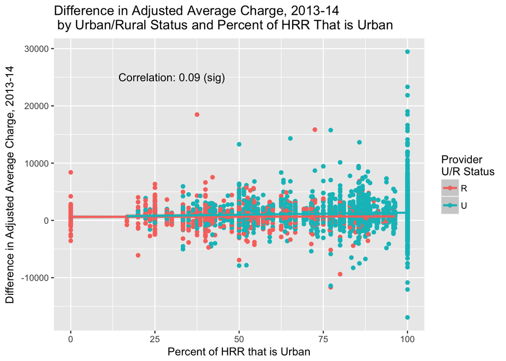

```r
#Summary stats and plots
#summary stats by rural/urban
stargazer(d %>% group_by(URBAN_RURAL_IND) %>%
  summarise(count = n(),
            avg = mean(DIFF_14_13_ADJUSTED_AVG_CHG, na.rm = T),
            median = median(DIFF_14_13_ADJUSTED_AVG_CHG, na.rm = T),
            stdv = sd(DIFF_14_13_ADJUSTED_AVG_CHG, na.rm = T),
            min = min(DIFF_14_13_ADJUSTED_AVG_CHG, na.rm = T),
            max = max(DIFF_14_13_ADJUSTED_AVG_CHG, na.rm = T)) %>%
    data.frame(), type = "text", summary = F,
  title = "Difference in Adjusted Average Charge, 2013-14 by Urban/Rural" )

#density plot. massive overlap between rural and urban
ggplot(d, aes(DIFF_14_13_ADJUSTED_AVG_CHG, fill = URBAN_RURAL_IND, colour = URBAN_RURAL_IND)) +
  geom_density(alpha = .3) +
  ggtitle("Difference in Adjusted Average Charge, 2013-14 by Urban/Rural") +
  labs(x = "Difference in Adjusted Average Charge, 2013-14")

#Provider Status and Percent urban in HRR
#huge variability in the 100% urban section
#possible interaction
ggplot(data = d, aes(HRR_PERCENT_URBAN, DIFF_14_13_ADJUSTED_AVG_CHG, colour = factor(URBAN_RURAL_IND))) +
  geom_point() + geom_smooth(method = 'lm') +
  labs(colour = "Provider \nU/R Status",
         x ="Percent of HRR that is Urban",
         y = "Difference in Adjusted Average Charge, 2013-14") +
  ggtitle("Difference in Adjusted Average Charge, 2013-14\n by Urban/Rural Status and Percent of HRR That is Urban") +
  annotate("text", x = 30, y = 25000, label = "Correlation: 0.09 (sig)")

# Test correlation
cor.test(d$HRR_PERCENT_URBAN,d$DIFF_14_13_ADJUSTED_AVG_CHG)
```

#### EDA for covariates: hospital residency programs

Hospitals that have residency programs are likely to have different costs, and therefore different charges, than hospitals without residency programs. The output below explores the dependent variable distributions by residency status; there is significant overlap, suggesting that perhaps residency programs do not influence the dependent variable all that much. However, the presence of a residency program might hve a slight relationship to incrased charges for hospitals compared hospitals without a residency program. The scatterplot shows the percentage of each HRR that has a residency program against the dependent variable, which is a slightly significanct correlation. These variables will be explored in the final regression models.

```
##
## Providers With/Out Residency Programs
## ==================================================================================
##   RESIDENCY_PROGRAM_IND count    avg     median     stdv        min        max
## ----------------------------------------------------------------------------------
## 1           N           2,031  929.911   731.977  2,529.110 -16,943.200 29,461.290
## 2           Y           1,043 1,299.031 1,015.754 2,568.770 -12,064.910 19,036.980
## ----------------------------------------------------------------------------------
```

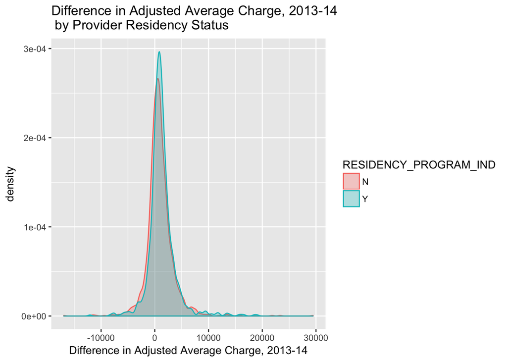

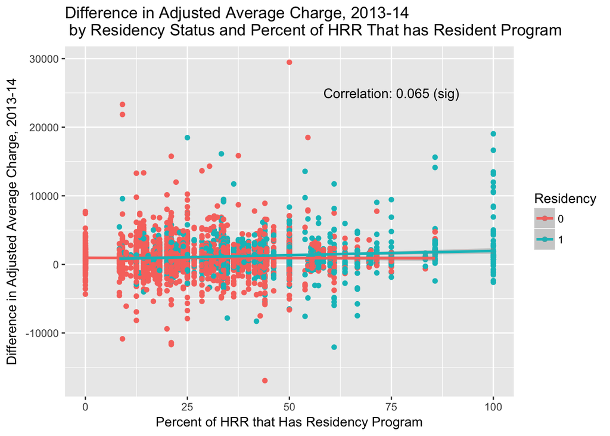

```r
#summary stats by residency
stargazer(d %>% group_by(RESIDENCY_PROGRAM_IND) %>%
  summarise(count = n(),
            avg = mean(DIFF_14_13_ADJUSTED_AVG_CHG, na.rm = T),
            median = median(DIFF_14_13_ADJUSTED_AVG_CHG, na.rm = T),
            stdv = sd(DIFF_14_13_ADJUSTED_AVG_CHG, na.rm = T),
            min = min(DIFF_14_13_ADJUSTED_AVG_CHG, na.rm = T),
            max = max(DIFF_14_13_ADJUSTED_AVG_CHG, na.rm = T)) %>%
    data.frame(), type = "text", summary = F,
  title = "Providers With/Out Residency Programs")

#density plot
ggplot(d, aes(DIFF_14_13_ADJUSTED_AVG_CHG, fill = RESIDENCY_PROGRAM_IND, colour = RESIDENCY_PROGRAM_IND)) +
  geom_density(alpha = .3) +
  labs(x = "Difference in Adjusted Average Charge, 2013-14") +
  ggtitle("Difference in Adjusted Average Charge, 2013-14\n by Provider Residency Status")

#same trend as urban/rural, though interaction effect looks potentially significant
#providers who are the only
ggplot(data = d, aes(HRR_PERCENT_RESIDENT, DIFF_14_13_ADJUSTED_AVG_CHG, colour = factor(RESIDENCY_PROGRAM_DUMMY))) +
  geom_point() + geom_smooth(method = 'lm') +
  labs(colour = "Residency", x = "Percent of HRR that Has Residency Program", y = "Difference in Adjusted Average Charge, 2013-14") +
  ggtitle("Difference in Adjusted Average Charge, 2013-14\n by Residency Status and Percent of HRR That has Resident Program") +
  annotate("text", x = 75, y = 25000, label = "Correlation: 0.065 (sig)")

# Correlation test
cor.test(d$HRR_PERCENT_RESIDENT,d$DIFF_14_13_ADJUSTED_AVG_CHG)
```

#### EDA for covariates: discharges per bed count

Discharges per bed is a proxy for the health of provider (pun intended). More discharges per bed means that a hospital is doing better business relative to its capacity. We used two variables for discharges per bed count. 1) 2013 discharges per bed gauges the health of provider against other providers, 2) the difference in discharges between 2013 and 2012 gauges the health of a provider relative to itself.

From the scatterplots below, it appears that there is a major outlier in the discharges per bed variable, which will have to be considered when building the final model.

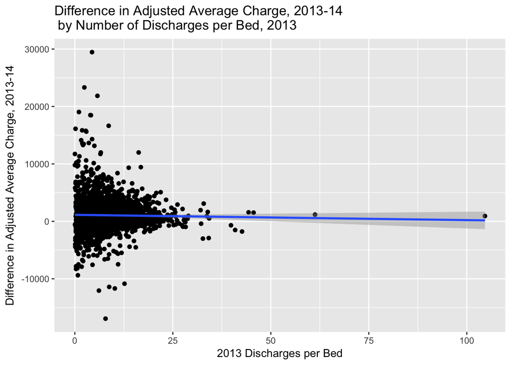

```r
#2013 discharges
#potential outlier situation. see what it looks like in final model
ggplot(d, aes(FY2013_DISCHARGES_PER_BED, DIFF_14_13_ADJUSTED_AVG_CHG)) +
  geom_point() + geom_smooth(method = 'lm') +
  labs(x = "2013 Discharges per Bed", y = "Difference in Adjusted Average Charge, 2013-14") +
  ggtitle("Difference in Adjusted Average Charge, 2013-14\n by Number of Discharges per Bed, 2013")
```

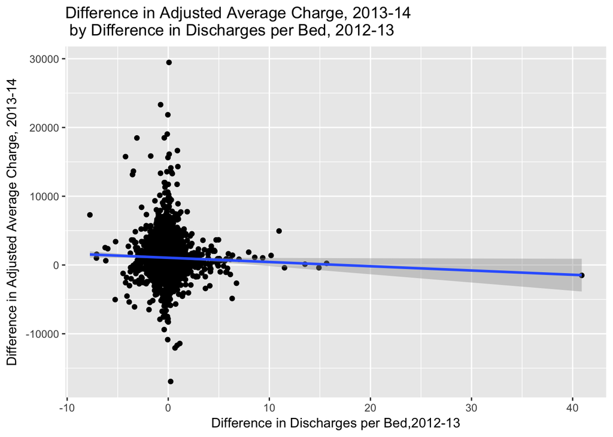

```r
#change in discharges, 2012-13
#potential outlier situation. see what it looks like in final model
ggplot(d, aes(DIFF_13_12_DISCHARGES_PER_BED, DIFF_14_13_ADJUSTED_AVG_CHG)) +
  geom_point() + geom_smooth(method = 'lm') +
  labs(x = "Difference in Discharges per Bed,2012-13", y = "Difference in Adjusted Average Charge, 2013-14") +
  ggtitle("Difference in Adjusted Average Charge, 2013-14\n by Difference in Discharges per Bed, 2012-13")
```

#### EDA for covariates: change in ownership

A change in ownership can mean big changes for a hospital, especially when it comes to charges. We would be remiss if we did not include this variable as part of our analysis. Indeed, comparing the two distributions of hospitals with and without ownership changes, hospitals with changes in owership have a very strange distribution. There are some hospitals for which a change in ownership meant decreasing costs, and other hospitals for which a change in ownership meant drastically increasing costs. This curve is definitely not normal, and this variable will have to be accounted for in regression analysis.

```r
#summary stats by change in ownership status
stargazer(d %>% group_by(CHANGE_OF_OWNERSHIP_IN_PERIOD) %>%
  summarise(count = n(),
            avg = mean(DIFF_14_13_ADJUSTED_AVG_CHG, na.rm = T),
            median = median(DIFF_14_13_ADJUSTED_AVG_CHG, na.rm = T),
            stdv = sd(DIFF_14_13_ADJUSTED_AVG_CHG, na.rm = T),
            min = min(DIFF_14_13_ADJUSTED_AVG_CHG, na.rm = T),
            max = max(DIFF_14_13_ADJUSTED_AVG_CHG, na.rm = T)) %>%
    data.frame(), type = "text",
  title = "Change in Ownership?",summary = F)
```

```
##
## Change in Ownership?
## ==========================================================================================
##   CHANGE_OF_OWNERSHIP_IN_PERIOD count    avg     median     stdv        min        max
## ------------------------------------------------------------------------------------------
## 1               N               2,969 1,016.364  806.774  2,377.777 -16,943.200 19,036.980
## 2               Y                105  2,151.939 1,068.040 5,409.192 -5,170.143  29,461.290
## ------------------------------------------------------------------------------------------
```

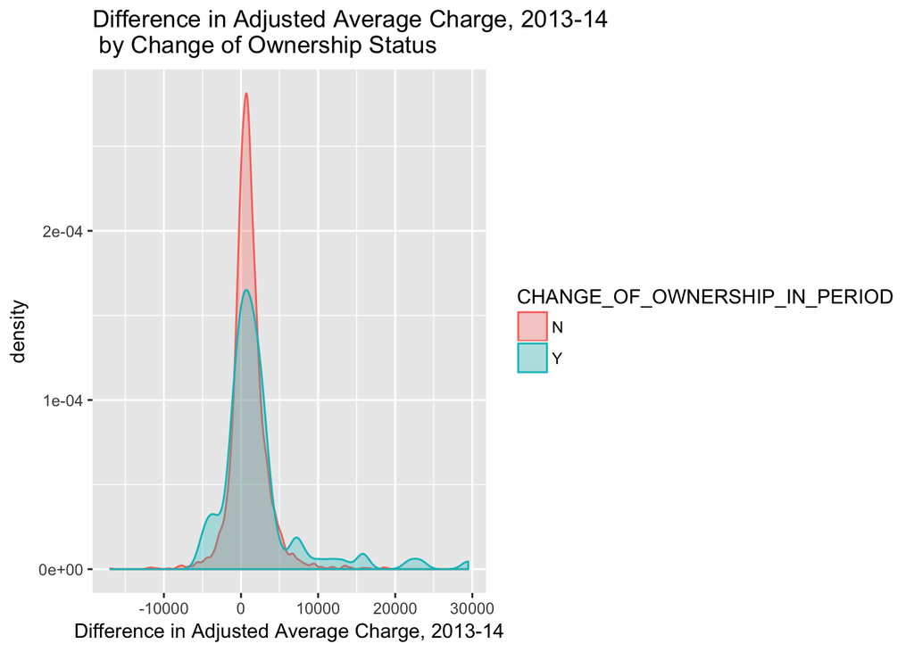

```r
#density plot
ggplot(d, aes(DIFF_14_13_ADJUSTED_AVG_CHG, fill = CHANGE_OF_OWNERSHIP_IN_PERIOD, colour = CHANGE_OF_OWNERSHIP_IN_PERIOD)) +
  geom_density(alpha = .3) +
  labs(x = "Difference in Adjusted Average Charge, 2013-14") +
  ggtitle("Difference in Adjusted Average Charge, 2013-14\n by Change of Ownership Status")
```

#### EDA for covariates: hospital for-profit

For profit hospitals likely have different charge schemes than hospitals that are not for profit, and therefore we will be including these in analysis. There were many types of hospitals available in the original dataset, leading to too many groups to be interesting or relevant. Therefore, we decided to group by profit status, as this is likely the dimension that has the largest effect on hospital charges.

```r
# Calculate % of providers that are for profit
mean(d$OWNERSHIP_FOR_PROFIT)

#summary stats by for profit status
stargazer(d %>% group_by(OWNERSHIP_FOR_PROFIT) %>%
  summarise(count = n(),
            avg = mean(DIFF_14_13_ADJUSTED_AVG_CHG, na.rm = T),
            median = median(DIFF_14_13_ADJUSTED_AVG_CHG, na.rm = T),
            stdv = sd(DIFF_14_13_ADJUSTED_AVG_CHG, na.rm = T),
            min = min(DIFF_14_13_ADJUSTED_AVG_CHG, na.rm = T),
            max = max(DIFF_14_13_ADJUSTED_AVG_CHG, na.rm = T)) %>%
    data.frame(), type = "text",
  title = "Private, For Profit Provider",summary = F)

#density plot
ggplot(d, aes(DIFF_14_13_ADJUSTED_AVG_CHG, fill = OWNERSHIP_FOR_PROFIT, colour = OWNERSHIP_FOR_PROFIT)) +
  geom_density(alpha = .3) +
  labs(x = "Difference in Adjusted Average Charge, 2013-14") +
  ggtitle("Difference in Adjusted Average Charge, 2013-14\n by For Profit Status")
```

### Step 3: Building a Regression model

#### Bivariate Model

After exploring the outcome and predictor variables and the relationships between them, we build a bivariate linear regression model between the main predictor of interest (adjusted average charge relative to HRR competition) and the main outcome of interest (adjusted change in average charge for hospital service between 2013 and 2014). The model returns a statistically significant relationship between the two variables when using hetero-skedastic robust errors: for every 1% that a hospital charges above its competitors in 2013, the hospital shows an adjusted charge incerase of $6.11 for 2014. However, this is not necessarily practically significant; when adjusted charges are on the order of thousands of dollars, a $6 increase per percentage point is not all that important. Indeed, this coefficient is only .24% of one standard deviation of the dependent variable.

This relationship does seem to echo what we saw in the scatterplots earlier, counter-intuitive to our hypothesis: this model suggests that hospitals that already charge more than their competitors in 2013 increase charges even more in 2014.

The residuals for this model, however, are not normally distributed and are not homoskedastic. We will add other explanatory variables to explain more of the residual error in the model.

```r
# Bivariate linear regression model, adjusted
adj_model0 = lm(DIFF_14_13_ADJUSTED_AVG_CHG ~ FY2013_ADJUSTED_AVG_CHG_RELATIVE_EX , data = d)
# Examining the model
stargazer(adj_model0,
          type = "text",
          dep.var.labels = "Difference in Adjusted Average Charge, 2013-14",
          title = "Bivariate Model",
          covariate.labels = c("Average Adjusted Charge Relative to HRR, 2013 (%)"))

# Not hugely practically significant
# coefficient is .24% of one sd of dependent variable
adj_model0$coefficients[2]/sd(d$DIFF_14_13_ADJUSTED_AVG_CHG, na.rm = T) * 100

# Checking for normally distributed residuals
hist(adj_model0$residuals, breaks = 50)
shapiro.test(adj_model0$residuals) # significant, reject null

# Checking for residual heteroskedasticity
bptest(adj_model0) # significant, reject null of homoskedasticity
se_adj_model0 = robust.se(adj_model0)[,2] # Use heteroskedastic robust SEs to be safe

# Final output with heteroskedastic robust errors
stargazer(adj_model0,
          type = "text",
          dep.var.labels = "Difference in Adjusted Average Charge, 2013-14",
          title = "Bivariate Model",
          covariate.labels = c("Average Relative Charge, 2013"),
          se = list(se_adj_model0 ))

# Check for overall significance
waldtest(adj_model0) # significant
```

```
## [1] "Robust Standard Errors"
```

```
##
## Bivariate Model
## ============================================================================
##                                            Dependent variable:
##                               ----------------------------------------------
##                               Difference in Adjusted Average Charge, 2013-14
## ----------------------------------------------------------------------------
## Average Relative Charge, 2013                    6.106***
##                                                  (1.605)
##
## Constant                                       1,098.322***
##                                                  (48.560)
##
## ----------------------------------------------------------------------------
## Observations                                      3,074
## R2                                                0.007
## Adjusted R2                                       0.007
## Residual Std. Error                       2,539.334 (df = 3072)
## F Statistic                              22.545*** (df = 1; 3072)
## ============================================================================
## Note:                                            *p<0.1; **p<0.05; ***p<0.01
```

#### Adding covariates: beneficiairies per provider in HRR

```r
# Adding beneficiaries per provider to model
adj_model1 = lm(data = d, DIFF_14_13_ADJUSTED_AVG_CHG ~ FY2013_ADJUSTED_AVG_CHG_RELATIVE_EX +BENEFICIARIES_PER_PROVIDER)

# Use robust se
se_adj_model1 = robust.se(adj_model1)[,2]

# Check for overall significance
waldtest(adj_model1) # significant

# Visualize output with both models
stargazer(adj_model0, adj_model1,
          type = "text",
          dep.var.labels = "Difference in Adjusted Average Charge, 2013-14",
          title = "With Beneficiaries per Provider",
          covariate.labels = c("Average Relative Charge, 2013",
                               "Avg Number of Beneficiaries per Provider (thousands)"),
          se = list(se_adj_model0, se_adj_model1 ))

# Compare models based on AIC
AIC(adj_model0,adj_model1)
```

```
## [1] "Robust Standard Errors"
```

```
##
## With Beneficiaries per Provider
## ======================================================================================================
##                                                                     Dependent variable:
##                                                      -------------------------------------------------
##                                                       Difference in Adjusted Average Charge, 2013-14
##                                                                (1)                      (2)
## ------------------------------------------------------------------------------------------------------
## Average Relative Charge, 2013                                6.106***                 5.730***
##                                                              (1.605)                  (1.619)
##
## Avg Number of Beneficiaries per Provider (thousands)                                 37.502***
##                                                                                       (10.201)
##
## Constant                                                   1,098.322***              675.475***
##                                                              (48.560)                (129.094)
##
## ------------------------------------------------------------------------------------------------------
## Observations                                                  3,074                    3,074
## R2                                                            0.007                    0.011
## Adjusted R2                                                   0.007                    0.010
## Residual Std. Error                                   2,539.334 (df = 3072)    2,534.962 (df = 3071)
## F Statistic                                          22.545*** (df = 1; 3072) 17.114*** (df = 2; 3071)
## ======================================================================================================
## Note:                                                                      *p<0.1; **p<0.05; ***p<0.01
```

The map below sheds some light on the overall distribution of HRR charges across the United States. The HRR’s with the highest average adjusted charges are located in large cities and populated areas, for the most part (such as California and New York). There are pockets of moderately expensive HRR’s near large metropolitan areas like Chicago and Houston. Notably, Florida seems to have HRR’s with high average charges statewide; this is perhaps due to their large population of older adults and retirees. For the most part, the Midwest, Midatlantic and Southern regions all seem to have relatively low average adjusted charges.

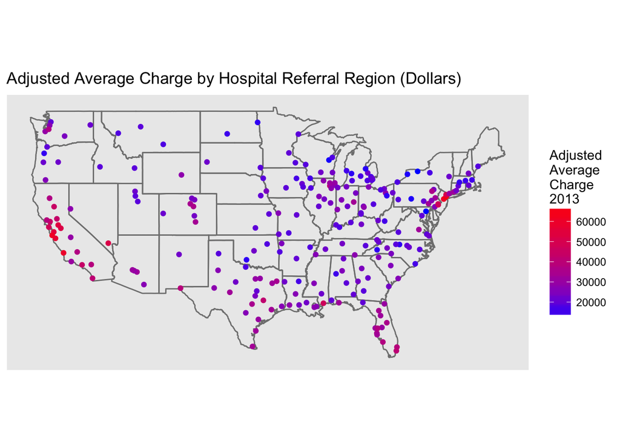

```r
all_cities = us.cities %>%
  unite(HRR, c(country.etc, name), sep = " - ", remove = F) %>%
  separate(HRR, into = c("HRR", "State"), sep = -4) %>%
  select(-State) %>% rename(lon = long)
HRR = HRR %>% left_join(all_cities, by = "HRR")
usa = map_data("state") %>%
  select(lon = long, lat, group, id = subregion)
ggplot(HRR %>% filter(country.etc != 'AK' , country.etc != "HI"), aes(lon, lat)) +
  geom_polygon(aes(group = group), usa, fill = NA, colour = "grey50") +
  geom_point(aes(colour = FY2013_ADJUSTED_AVG_CHG)) +
  coord_quickmap() +
  labs(colour = "Adjusted\nAverage\nCharge\n2013", y = NULL, x = NULL) +
  ggtitle('Adjusted Average Charge by Hospital Referral Region (Dollars)') +
  scale_x_continuous(breaks = NULL, labels = NULL) +
  scale_y_continuous(breaks = NULL, labels = NULL) +
  scale_colour_gradient(low = "blue",high = "red")
```

area for future research: normalize based on inflation relative to place (CA and NY more expensive in general, etc) explore age of population as a contributor